# Regresión Lineal Simple

Eduardo Marín Nicolalde

Para el siguiente ejemplo requerimos el paquete "**MASS**" (Modern Applied Statistics with S), mismo que contiene bases de datos reales para practicar modelización estadística.

```r
library(MASS)
```

# Dataset Boston:

Precio medio de casas (medv) en 506 barrios en Boston. Buscamos predecir el precio y disponemos de 13 variables. Más información sobre la base de datos en http://www.cs.toronto.edu/~delve/data/boston/bostonDetail.html

**Explorando la base de datos**

```r
dim(Boston)
```

1. 506

2. 14

```r
str(Boston)
```

```
'data.frame':	506 obs. of  14 variables:
 $ crim   : num  0.00632 0.02731 0.02729 0.03237 0.06905 ...
 $ zn     : num  18 0 0 0 0 0 12.5 12.5 12.5 12.5 ...
 $ indus  : num  2.31 7.07 7.07 2.18 2.18 2.18 7.87 7.87 7.87 7.87 ...
 $ chas   : int  0 0 0 0 0 0 0 0 0 0 ...
 $ nox    : num  0.538 0.469 0.469 0.458 0.458 0.458 0.524 0.524 0.524 0.524 ...
 $ rm     : num  6.58 6.42 7.18 7 7.15 ...
 $ age    : num  65.2 78.9 61.1 45.8 54.2 58.7 66.6 96.1 100 85.9 ...
 $ dis    : num  4.09 4.97 4.97 6.06 6.06 ...
 $ rad    : int  1 2 2 3 3 3 5 5 5 5 ...
 $ tax    : num  296 242 242 222 222 222 311 311 311 311 ...
 $ ptratio: num  15.3 17.8 17.8 18.7 18.7 18.7 15.2 15.2 15.2 15.2 ...
 $ black  : num  397 397 393 395 397 ...
 $ lstat  : num  4.98 9.14 4.03 2.94 5.33 ...
 $ medv   : num  24 21.6 34.7 33.4 36.2 28.7 22.9 27.1 16.5 18.9 ...
```

```r
head(Boston)
```

| crim | zn | indus | chas | nox | rm | age | dis | rad | tax | ptratio | black | lstat | medv |
| --- | --- | --- | --- | --- | --- | --- | --- | --- | --- | --- | --- | --- | --- |
| 0.00632 | 18 | 2.31 | 0 | 0.538 | 6.575 | 65.2 | 4.0900 | 1 | 296 | 15.3 | 396.90 | 4.98 | 24.0 |
| 0.02731 | 0 | 7.07 | 0 | 0.469 | 6.421 | 78.9 | 4.9671 | 2 | 242 | 17.8 | 396.90 | 9.14 | 21.6 |
| 0.02729 | 0 | 7.07 | 0 | 0.469 | 7.185 | 61.1 | 4.9671 | 2 | 242 | 17.8 | 392.83 | 4.03 | 34.7 |
| 0.03237 | 0 | 2.18 | 0 | 0.458 | 6.998 | 45.8 | 6.0622 | 3 | 222 | 18.7 | 394.63 | 2.94 | 33.4 |
| 0.06905 | 0 | 2.18 | 0 | 0.458 | 7.147 | 54.2 | 6.0622 | 3 | 222 | 18.7 | 396.90 | 5.33 | 36.2 |
| 0.02985 | 0 | 2.18 | 0 | 0.458 | 6.430 | 58.7 | 6.0622 | 3 | 222 | 18.7 | 394.12 | 5.21 | 28.7 |

```r
names(Boston)
```

1. 'crim'

2. 'zn'

3. 'indus'

4. 'chas'

5. 'nox'

6. 'rm'

7. 'age'

8. 'dis'

9. 'rad'

10. 'tax'

11. 'ptratio'

12. 'black'

13. 'lstat'

14. 'medv'

Adjuntamos la base de datos al entorno para simplificar el código:

```r
attach(Boston)
```

# Comandos para regresión

La función **lm** (linear model) permite estimar regresiones lineales. Como argumento requerimos especificar el modelo deseado. Por ejemplo, para estimar el modelo $$y=\beta_0 + \beta_1 x$$ deberíamos especificar **y~x** en el argumento.

Para nuestro ejemplo, si queremos predecir **medv** (Valor mediano de casas ocupadas por el propietario en miles de dólares) en función de **lstat** (% de población de clase baja), tendríamos **medv~lstat**. El modelo entonces sería $$medv=\beta_0 + \beta_1 lstat$$. Guardamos los resultados de la regresión en el objeto **lm.fit**.

```r
lm.fit=lm(medv~lstat)
```

Si no hubieramos utilizado la función **attach()**, habríamos podido estimar la regresión utilizando el siguiente código:

```r
lm.fit =lm(medv∼lstat , data= Boston )
```

# Resultados del análisis:

Si invocamos solamente el nombre del objeto que contiene el resultado de la regresión, el output es limitado y solo contiene el valor de los coeficientes $\beta$ estimados.

```r
lm.fit
```

```
Call:
lm(formula = medv ~ lstat, data = Boston)

Coefficients:
(Intercept)        lstat
      34.55        -0.95
```

Podemos valernos de la función **summary()** para obtener un resultado mas detallado. Tenemos:

- Información sobre la distribución de los residuos (Cuartiles)
- Los coeficientes estimados con su Error Estándar (Std. Error **SE**), el valor del estadístico de test $t$ y su respectivo p-valor para probar la hipótesis $$H_0 : \beta_i=0$$ contra $$H_a : \beta_i \neq 0$$
- El Error Estándar de los Residuos (Residual Estándar Error **RSE**): $$\sqrt{\frac{1}{n-2}\sum(y_i-\hat{y}_i)^2}$$ como medida para cuantificar *el promedio de distancia entre la recta de regresión y la respuesta observada*.
- El estadístico $R^2$ para cuantificar la *proporción de varianza explicada* por el modelo.
- Prueba global F y su p-valor para probar la hipótesis $$H_0 : \beta_0=\beta_1=0$$ contra $$H_a : \text{al menos un } \beta_i \neq 0$$

```r
summary(lm.fit)
```

```
Call:
lm(formula = medv ~ lstat, data = Boston)

Residuals:
    Min      1Q  Median      3Q     Max
-15.168  -3.990  -1.318   2.034  24.500

Coefficients:
            Estimate Std. Error t value Pr(>|t|)
(Intercept) 34.55384    0.56263   61.41   <2e-16 ***
lstat       -0.95005    0.03873  -24.53   <2e-16 ***
---
Signif. codes:  0 '***' 0.001 '**' 0.01 '*' 0.05 '.' 0.1 ' ' 1

Residual standard error: 6.216 on 504 degrees of freedom
Multiple R-squared:  0.5441,	Adjusted R-squared:  0.5432
F-statistic: 601.6 on 1 and 504 DF,  p-value: < 2.2e-16
```

Tenemos también otros resultados producto de la estimación realizada. Para conocer los nombres con los que dichos resultados han sido almacendaos, utilizamos la función **names()**

```r
names(lm.fit)
```

1. 'coefficients'

2. 'residuals'

3. 'effects'

4. 'rank'

5. 'fitted.values'

6. 'assign'

7. 'qr'

8. 'df.residual'

9. 'xlevels'

10. 'call'

11. 'terms'

12. 'model'

**Coeficientes:**

```r
lm.fit$coefficients
```

**(Intercept)**

34.5538408793831

**lstat**

-0.95004935375799

**Residuos:** $$e_i=y_i - \hat{y}_i$$

```r
head(lm.fit$residuals)
```

**1**

-5.82259509766873

**2**

-4.27038978603514

**3**

3.97485801626161

**4**

1.63930422066539

**5**

6.709922176147

**6**

-0.904083746303966

**Valores ajustados:** $$\hat{y}_i=\hat{\beta}_0+\hat{\beta}_1 x_i$$

```r
head(lm.fit$fitted.values)
```

**1**

29.8225950976687

**2**

25.8703897860351

**3**

30.7251419837384

**4**

31.7606957793346

**5**

29.490077823853

**6**

29.604083746304

Utilizando el **error estándar de los coeficientes** $SE(\hat{\beta}_i)$ podemos obtener también intervalos de confianza. La función **confint()** realiza automáticamente los cálculos pertinentes.

Comparando los intervalos para distintos niveles de confianza observamos que, a mayor confianza más ancho el intervalo.

```r
confint(lm.fit,level = 0.95)
```

|  | 2.5 % | 97.5 % |
| --- | --- | --- |
| (Intercept) | 33.448457 | 35.6592247 |
| lstat | -1.026148 | -0.8739505 |

```r
confint(lm.fit,level = 0.99)
```

|  | 0.5 % | 99.5 % |
| --- | --- | --- |
| (Intercept) | 33.099101 | 36.0085810 |
| lstat | -1.050199 | -0.8498995 |

# Predicciones

Para hacer predicciones utilizando el modelo $$medv=\beta_0 + \beta_1 lstat$$ utilizamos la función **predict()**, un *data.frame* y el nombre de la variable $x$ junto los valores de interés.

Para predecir el precio medio de las viviendas **medv** de acuerdo a porcentajes dados de población de clase baja **lstat**, escribimos:

```r
predict(lm.fit , data.frame(lstat=c(5 ,10 ,15)))
```

**1**

29.8035941105931

**2**

25.0533473418032

**3**

20.3031005730132

Si queremos intervalos de predicción podemos añadir el argumento **interval** y un nivel de confianza deseado.

```r
predict(lm.fit , data.frame (lstat =c (5 ,10 ,15) ),
        interval ="prediction", level = 0.95)
```

|  | fit | lwr | upr |
| --- | --- | --- | --- |
| 1 | 29.80359 | 17.565675 | 42.04151 |
| 2 | 25.05335 | 12.827626 | 37.27907 |
| 3 | 20.30310 | 8.077742 | 32.52846 |

```r
predict(lm.fit , data.frame (lstat =c (5 ,10 ,15) ),
        interval ="prediction", level = 0.99)
```

|  | fit | lwr | upr |
| --- | --- | --- | --- |
| 1 | 29.80359 | 13.697884 | 45.90930 |
| 2 | 25.05335 | 8.963690 | 41.14300 |
| 3 | 20.30310 | 4.213921 | 36.39228 |

# Gráfico para regresión lineal simple

Iniciamos con el gráfico de dispersión y sobreponemos una recta con la función **abline()**. Los argumentos **lwd** y **col** determinan el ancho de la linea y el color respectivamente. Se puede encontrar los colores disponibles en http://www.stat.columbia.edu/~tzheng/files/Rcolor.pdf

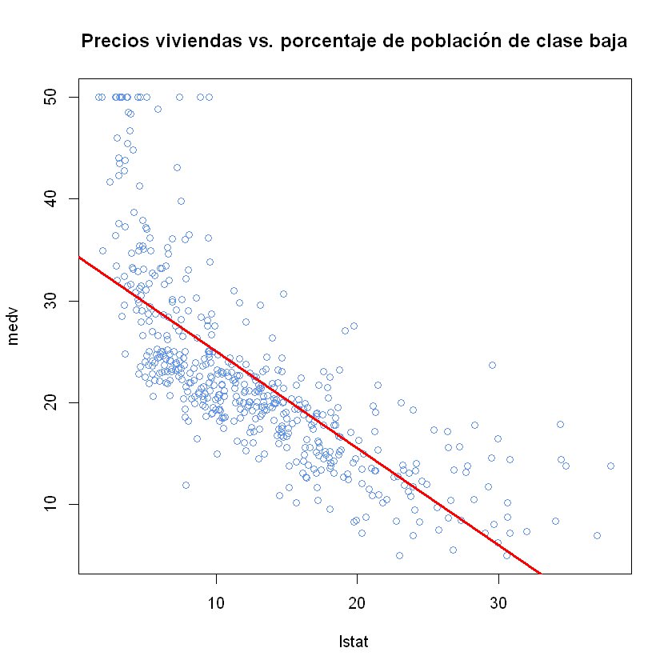

```r
plot(lstat, medv ,
         main="Precios viviendas vs. porcentaje de población de clase baja",
         col="cornflowerblue")
	abline(lm.fit,lwd=3,col="red")	# Color
```

Se puede modificar el tipo de puntos en el gráfico de dispersión con el argumento **pch**. Las opciones disponibles se encuentran en http://www.endmemo.com/program/R/pchsymbols.php

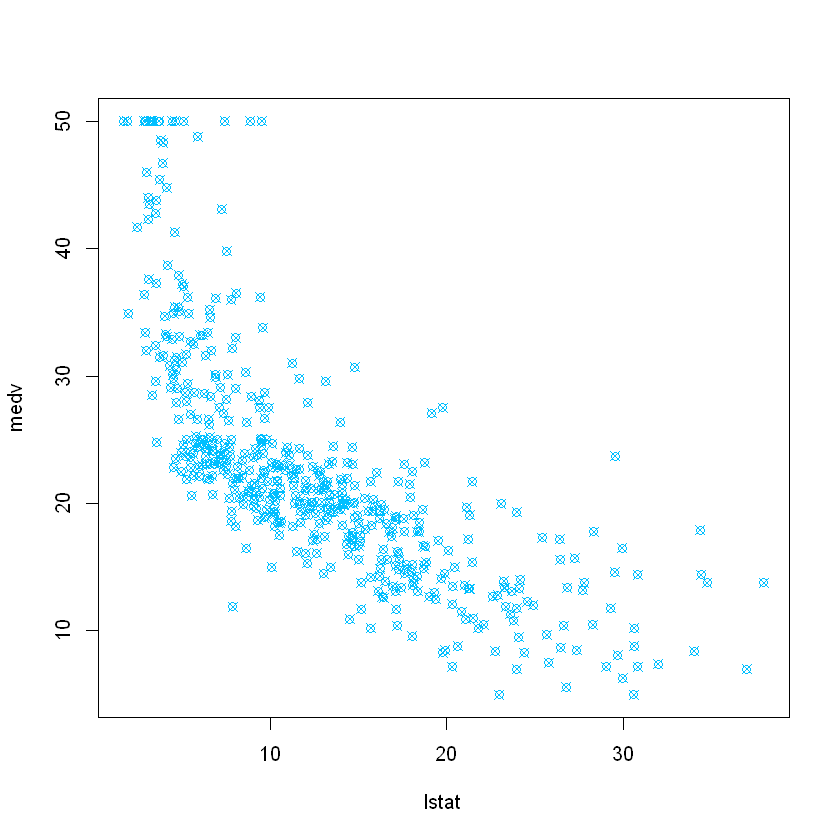

```r
# Tipo de puntos
	plot(lstat,medv,pch=13,col="deepskyblue")
```

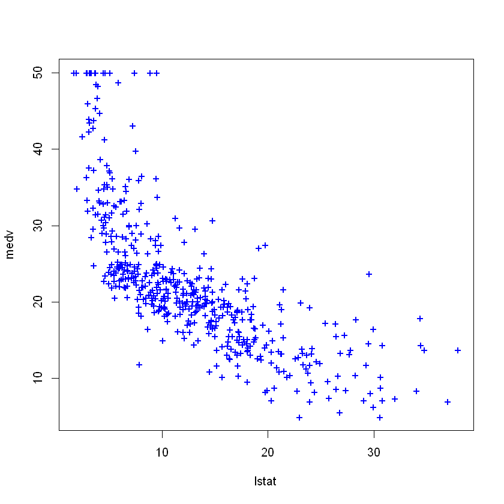

```r
plot(lstat,medv,pch="+", col="blue")
```

# Graficos múltiples

La función **par(mfrow=c("nfilas","ncolumnas"))** permite combinar distintos gráficos en un solo output. Así, **nfilas** y **ncolumnas** muestran el número de filas y columnasen las que se combinarán los gráficos.

Si utilizamos la función **plot()** sobre el objeto que contiene los resultados de la estimación, se obtienen 4 gráficos individuales que servirán para validar el modelo (a ver en las siguientes clases). Utilizando **par(mfrow=c("nfilas","ncolumnas"))** podemos obtener un resultado más estético en una úinica imagen. Los gráficos obtenidos representan:

- Gráfico de valores predichos $\hat{y}_i$ versus residuos $ei=y_i - \hat{y}_i$.
- Gráfico cuantil-cuantil (qq plot) para validar normalidad de los residuos.
- Gráfico "Scale-Location" para probar homoscedasticidad (varianza constante de los residuos). Los residuos deben estar distribuidos de la misma manera al compararlos con las predicciones.
- Gráfico "Residuals vs Leverage" para identificar observaciones influyentes (a tratar en las siguientes clases).

Más detalles en http://data.library.virginia.edu/diagnostic-plots/

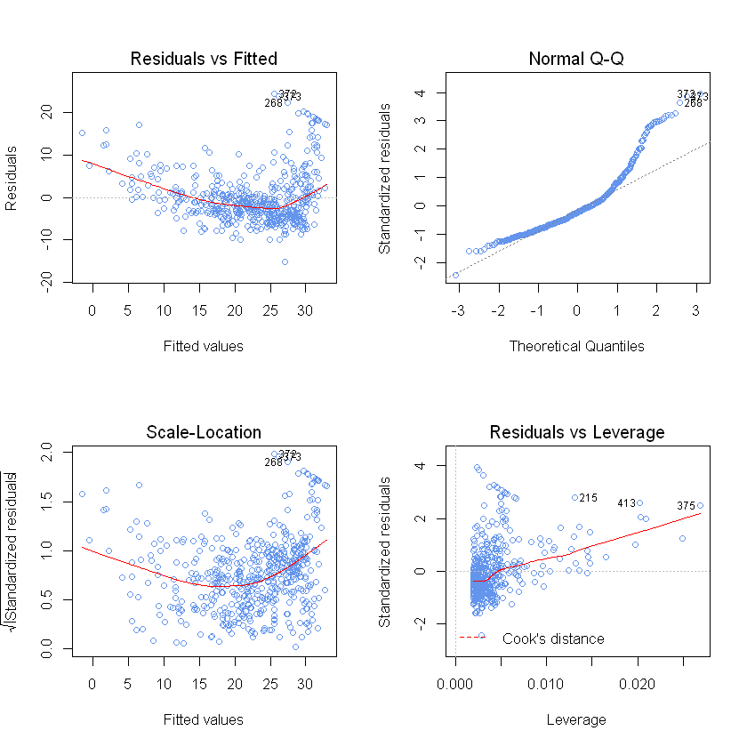

```r
par(mfrow=c(2,2))
    plot(lm.fit, col="cornflowerblue")
```

Terminamos la sesión "desligando" la base de datos de la sesión, para evitar posibles confusiones al continuar trabajando.

```r
detach(Boston)
```